# Cantidad de personas por zona o localidad

Diego Medina

11/10/2020

# Paquetes y preparación de datos espaciales

Estos son los paquetes o librerías que vamos a ocupar para poder hacer el análisis de los datos. Cada una se puede buscar en la pestaña *help* a la derecha de *Rstudio*.

```r
library(rgdal)
library(DBI)
```

```r
library(dplyr)
library(raster)
library(sf)
library(maptools)
library(rgeos)
options(scipen=999)
```

### Preparación datos espaciales

```r
Zonas_urbanas <- readShapePoly('R10/ZONA_C17.shp', IDvar=NULL)
Localidades_rurales <- readShapePoly('R10/LOCALIDAD_C17.shp', IDvar=NULL)
names(Zonas_urbanas) ### Se ven las columnas de la data
```

```
##  [1] "REGION"     "NOM_REGION" "PROVINCIA"  "NOM_PROVIN" "COMUNA"
##  [6] "NOM_COMUNA" "URBANO"     "DISTRITO"   "LOC_ZON"    "GEOCODIGO"
## [11] "SHAPE_Leng" "SHAPE_Area"
```

```r
names(Localidades_rurales)
```

```
##  [1] "REGION"     "NOM_REGION" "PROVINCIA"  "NOM_PROVIN" "COMUNA"
##  [6] "NOM_COMUNA" "DISTRITO"   "LOC_ZON"    "NOM_LOCALI" "GEOCODIGO"
## [11] "SHAPE_Leng" "SHAPE_Area"
```

### Filtrar por comuna en los datos espaciales

Para filtrar por comuna en el *.shp* hay que primero saber qué código es cada comuna según las cartografías del INE. Para consultar el manual del censista en este repositorio [click aquí](https://github.com/demcortillas/CENSO2017/blob/main/Manual_para-Censistas.pdf)

```r
PtoV_urb <- subset(Zonas_urbanas,COMUNA == 10109)
PtoV_rur <- subset(Localidades_rurales,COMUNA == 10109)
```

### Juntar los dos .shp

```r
Pto_varas_sp <- bind(PtoV_urb, PtoV_rur)
```

## Trabando con los Microdatos

Conexión con la base de datos y conexión con la tabla de personas

```r
con <- dbConnect(RSQLite::SQLite(), "D:/PROJECTS/db/CENSO2017/microdatos/MVE.db")
DB <- tbl(con, "PERSONAS")
```

### Filtrar por microdatos de comuna

```r
Pto_varas <- DB %>% filter(COMUNA==10109) %>% collect()
```

### ¿cuántas personas hay por zona o por localidad?

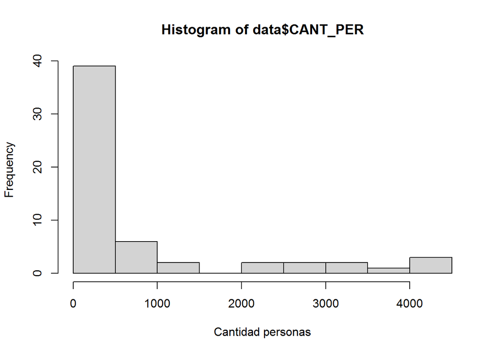

```r
GEOCODIGO<-unique(Pto_varas$ID_ZONA_LOC)
CANT_PER<-NULL

for(localidad in unique(Pto_varas$ID_ZONA_LOC)){
  A<-subset(Pto_varas,ID_ZONA_LOC == localidad)
  CANT_PER<-c(CANT_PER,dim(A)[1])
}

data<-data.frame(GEOCODIGO=as.character(GEOCODIGO),CANT_PER)

hist(data$CANT_PER,xlab='Cantidad personas')
```

### cruzar la data no espacial con la espacial mediante columna GEOCODIGO

```r
Pto_varas<-merge(x=Pto_varas_sp,y=data,by.x="GEOCODIGO",by.y="GEOCODIGO")
```

### Exportar en formato .shp

```r
writeOGR(obj=Pto_varas, dsn="out", layer="Pto_varas", driver="ESRI Shapefile",overwrite_layer=TRUE)
```

# Discusión metodológica

A este nivel de agregación podemos trabajar con el cruce de variables que querramos. Pero existe un segundo método bastante importante. Mediante el siguiente *.shp* podemos acceder a la cantidad de personas a nivel de entidad rural y podemos comparar las densidades. La entidad es un nivel más desagregado equivalente a la manzana censal pero a nivel rural, pero que solamente puedes acceder a la cantidad de personas o viviendas que viven ahí y no se puede cruzar con ninguna otra variable porque el ine no facilita los datos

```r
Entidades<- shapefile('R10/ENTIDAD_IND_C17.shp')
Entidad_pto_varas <- subset(Entidades,COMUNA == 10109)
Entidad_pto_varas <- spTransform(Entidad_pto_varas, crs("+init=epsg:32719"))
```

```r
densidad <- Entidad_pto_varas@data$TOTAL_PERS / (area(Entidad_pto_varas)/10000)
```

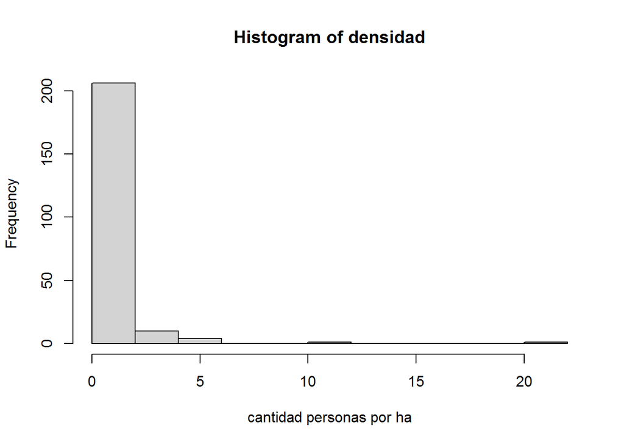

```r
hist(densidad,xlab='cantidad personas por ha')
```

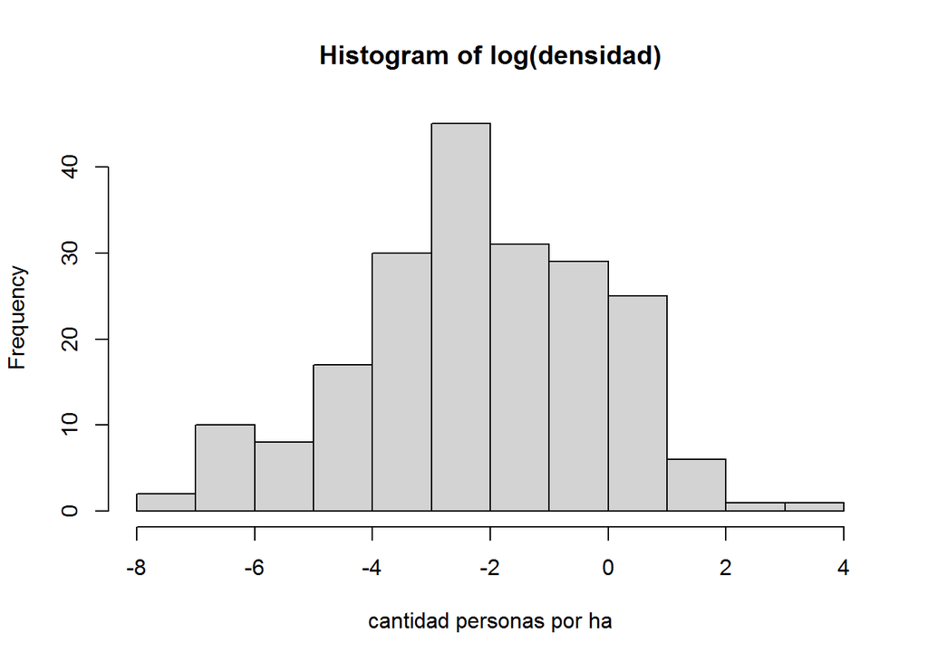

```r
hist(log(densidad),xlab='cantidad personas por ha')
```

Entonces tienes las *ENTIDADES* con su respectiva densidad o puedes tener las *LOCALIDADES* para cualquier otro cruce de variables disponibles en el censo. Para más información de las bases de datos del censo y cómo estas funcionan [click aquí](https://github.com/demcortillas/CENSO2017).